# Movie_Ratings_Project

Kashish Gupta

2024-11-01

**Analyzing Movie Ratings**

#INTRODUCTION

- Title: Movies’ ratings versus user votes
- Usually, we can find a lot of information online about the ranking of movies, universities, supermarkets, etc. We can use these data to supplement information from another database or facilitate trend analysis. However, it’s not easy to choose the right criterion because several might be interesting (e.g., movies’ ratings and user votes). In this project, we want to extract information on the most popular movies from early 2020 and check if the ratings are in alignment with the votes. If yes, then we can consider either one or the other without loss of information.

##ABOUT THE GOAL: - we want to extract data from the top 30 movies between March and July 2020. We can extract various details, including a movie’s title, description, actors, director, genre, runtime, and ratings. - Then, we want to check whether ratings correlate to user votes.

# Loading the packages

```r
install.packages("rvest")
install.packages("dplyr")
```

```r
install.packages("ggplot2")
install.packages("readr")
install.packages("stringr")
install.packages("tibble")
library("rvest")
library("dplyr")
library("ggplot2")
library("readr")
library("stringr")
library("tibble")
```

#loading the web page

```r
url <- "https://dataquestio.github.io/web-scraping-pages/IMDb-DQgp.html"
wp_content = read_html(url)
```

# String Manipulation Reminder

```r
as.numeric("10.50")
```

```
## [1] 10.5
```

```r
as.numeric(c("14.59", "3.14", "55"))
```

```
## [1] 14.59  3.14 55.00
```

```r
readr::parse_number(c("14 min", "17,35", "(2012)", "1,2,3,4"))
```

```
## [1]   14 1735 2012 1234
```

```r
stringr::str_trim(" Spaces before and after should disappear    ")
```

```
## [1] "Spaces before and after should disappear"
```

# Extracting Elements from the Header

First, we want to extract the movies’ titles and release years.

```r
# Extracting the movie's titles
## Finding the title CSS selector
title_selector <- ".lister-item-header a"
## Identifying the number of elements this selector will select from Selector Gadget
n_title <- 30
## Extracting the movie titles combining the `html_nodes()` and `html_text()` function
titles <- wp_content %>%
  html_nodes(title_selector) %>%
  html_text()
## Printing titles vector
titles
```

```
##  [1] "Mulan"
##  [2] "The Call"
##  [3] "Greenland"
##  [4] "Don't Listen"
##  [5] "Unhinged"
##  [6] "Ava"
##  [7] "The Hunt"
##  [8] "Ghosts of War"
##  [9] "Hamilton"
## [10] "The Old Guard"
## [11] "The Secret: Dare to Dream"
## [12] "The Outpost"
## [13] "Extraction"
## [14] "Train to Busan Presents: Peninsula"
## [15] "Greyhound"
## [16] "The King of Staten Island"
## [17] "A Quiet Place Part II"
## [18] "Bloodshot"
## [19] "The Dark and the Wicked"
## [20] "Arkansas"
## [21] "The Rental"
## [22] "Trolls World Tour"
## [23] "Sputnik"
## [24] "Eurovision Song Contest: The Story of Fire Saga"
## [25] "Inheritance"
## [26] "Spenser Confidential"
## [27] "The Tax Collector"
## [28] "The Way Back"
## [29] "The Silencing"
## [30] "Archive"
```

```r
# Extracting the movie's years
## Using a process similar to the one we used to extract the titles
year_selector <- ".lister-item-year"
n_year <- 30
years <- wp_content %>%
  html_nodes(year_selector) %>%
  html_text()
## Converting the years from character to numeric data type
years <- readr::parse_number(years)
## Printing years vector
years
```

```
##  [1] 2020 2020 2020 2020 2020 2020 2020 2020 2020 2020 2020 2020 2020 2020 2020
## [16] 2020 2020 2020 2020 2020 2020 2020 2020 2020 2020 2020 2020 2020 2020 2020
```

# Extracting Movie’s Features

We want now to extract the movie’s runtimes and genres.

```r
# Extracting the movie's runtimes
## Finding the runtime CSS selector
runtime_selector <- ".runtime"
## Identifying the number of elements this selector will select from Selector Gadget
n_runtime <- 30
## Extracting the movie runtimes combining the `html_nodes()` and `html_text()` function
runtimes <- wp_content %>%
  html_nodes(runtime_selector) %>%
  html_text()
## Converting the runtimes from character to numeric data type
runtimes <- readr::parse_number(runtimes)
## Printing runtimes vector
runtimes
```

```
##  [1] 115 112 119  97  90  96  90  94 160 125 107 123 116 116  91 136  97 109  95
## [20] 117  88  90 113 123 111 111  95 108  93 109
```

```r
# Extracting the movie's genres
## Extracting the movie genres using a similar process as previously
genre_selector <- ".genre"
n_genre <- 30
genres <- wp_content %>%
  html_nodes(genre_selector) %>%
  html_text()
## Removing whitespaces at the end of genre characters
genres <- stringr::str_trim(genres)
## Printing genres vector
genres
```

```
##  [1] "Action, Adventure, Drama"     "Horror, Mystery, Thriller"
##  [3] "Action, Drama, Thriller"      "Drama, Horror, Thriller"
##  [5] "Action, Thriller"             "Action, Crime, Drama"
##  [7] "Action, Horror, Thriller"     "Horror, Thriller, War"
##  [9] "Biography, Drama, History"    "Action, Adventure, Fantasy"
## [11] "Drama, Romance"               "Action, Drama, History"
## [13] "Action, Thriller"             "Action, Horror, Thriller"
## [15] "Action, Drama, History"       "Comedy, Drama"
## [17] "Drama, Horror, Sci-Fi"        "Action, Drama, Sci-Fi"
## [19] "Horror"                       "Crime, Drama, Thriller"
## [21] "Horror, Thriller"             "Animation, Adventure, Comedy"
## [23] "Drama, Horror, Sci-Fi"        "Comedy, Music"
## [25] "Drama, Mystery, Thriller"     "Action, Comedy, Crime"
## [27] "Action, Crime, Drama"         "Drama, Sport"
## [29] "Action, Crime, Thriller"      "Drama, Sci-Fi, Thriller"
```

# Extract the movies’ user ratings.

We’re now extracting the user ratings and metascores.

```r
# Extracting the movies user rating
## Find the use rating CSS selector and assign the result to a variable.
user_rating_selector <- ".ratings-imdb-rating"
## Identify the number of elements this selector will select from Selector Gadget
n_user_rating <- 29
## Extract the user ratings, combining the html_nodes() and html_attr() functions
user_ratings <- wp_content%>%
  html_nodes(user_rating_selector)%>%
  html_attr("data-value")
## Convert the user ratings from character to numeric data type
user_ratings <- as.numeric(user_ratings)
## Print the user_ratings vector
user_ratings
```

```
##  [1] 5.5 7.2 6.3 6.1 6.0 5.3 6.5 5.5 8.6 6.6 6.4 6.8 6.7 5.4 7.0 7.1 5.7 6.2 5.9
## [20] 5.7 6.1 6.4 6.5 5.5 6.2 4.7 6.7 6.1 6.3
```

```r
#Extract the movies' metascores
## Find the metascore CSS selector and assign the result to a variable.
metascore_selector <- ".metascore"
## Identify the number of elements this selector will select from Selector Gadget
n_metascore <- 25
## Extract the metascores, combining the html_nodes() and html_attr() functions
metascores <- wp_content%>%
  html_nodes(metascore_selector)%>%
  html_text()
## Remove whitespaces at the end of metascores and convert them into numeric data type
metascores <- stringr::str_trim(metascores)
metascores <- as.numeric(metascores)
## Print the metascores vector
metascores
```

```
##  [1] 66 40 39 50 38 90 70 32 71 56 51 64 67 44 72 55 63 51 61 50 31 49 22 66 67
```

# Extracting the Movies’ Votes

```r
# Extract the movies' votes
## Find the vote CSS selector, and assign the result to a variable
vote_selector <- ".sort-num_votes-visible :nth-child(2)"
## Identify the number of elements this selector will select from Selector Gadget
n_vote <- 29
## Extract the votes, combining the html_nodes() and html_text() functions
votes <- wp_content%>%
  html_nodes(vote_selector)%>%
  html_text()
## Convert the votes from character to numeric data type
votes <- readr::parse_number(votes)
## Print the votes vector
votes
```

```
##  [1]  80231   6559  27482   4879  25316  20882  62277   4886  48663 117211
## [11]   5420  17001 151319  16815  60885  29278  57763   3701   7951  13965
## [21]  14792  10516  69186   7837  65768   7416  28300   9355   9271
```

# Dealing with Missing Values

We’ve extracted the titles, years, runtimes, genres, user ratings, metascores, and votes from our web page.

- We can now combine them using the tibble() function. Since we’re missing some data, this operation will throw an error.
- Exploring the web page again, we notice that the 17th movie is partly the cause of this problem. Furthermore, movies 2, 3, 4, 17, and 29 don’t have metascores.
- Introduce NA values in the metascores vector. - Remove the 17th element from all the vectors with a length of 30.

To insert NA into the metascores vector at positions 2, 3, 4, 17, and 29, we have to provide the following positions to our function: 1, 1, 1, 13, and 24. They are the positions after which to insert NA.

```r
# Copy-pasting the `append_vector()` in our Markdown file
append_vector <- function(vector, inserted_indices, values){

  ## Creating the current indices of the vector
  vector_current_indices <- 1:length(vector)

  ## Adding small amount of values (between 0 and 0.9) to the `inserted_indices`
  new_inserted_indices <- inserted_indices + seq(0, 0.9, length.out = length(inserted_indices))

  ## Appending the `new_inserted_indices` to the current vector indices
  indices <- c(vector_current_indices, new_inserted_indices)

  ## Ordering the indices
  ordered_indices <- order(indices)

  ## Appending the new value to the existing vector
  new_vector <- c(vector, values)

  ## Ordering the new vector wrt the ordered indices
  new_vector[ordered_indices]
}
# Using the append_vector() function to insert NA into the metascores vector after the positions 1, 1, 1, 13, and 24.
metascores <- append_vector(metascores,c(1, 1, 1, 13, 24), NA)
metascores
```

```
##  [1] 66 NA NA NA 40 39 50 38 90 70 32 71 56 51 64 67 NA 44 72 55 63 51 61 50 31
## [26] 49 22 66 NA 67
```

```r
# Remove the 17th element from the vectors: titles, years, runtimes, genres, and metascores
## Save the result back to these vectors
titles <- titles[-17]
years <- years[-17]
runtimes <- runtimes[-17]
genres <- genres[-17]
metascores <- metascores[-17]
```

# Putting It All Together and Visualizing

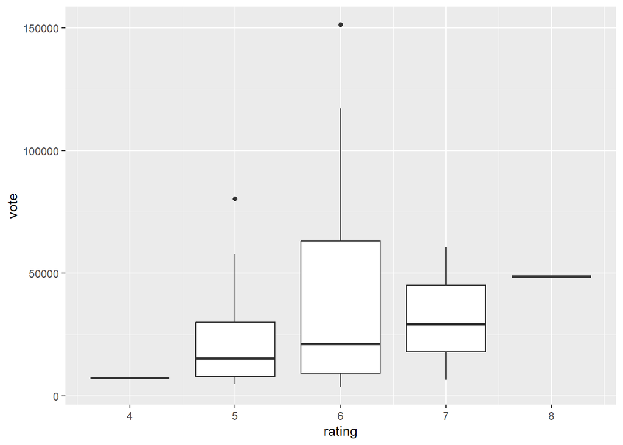

```r
# Create a dataframe with the data we previously extracted: titles, years, runtimes, genres, user ratings, metascores, and votes
## Keep only the integer part of the user ratings using the floor() function. For example, 3.4 becomes 3.
movie_df <- tibble::tibble("title" = titles,
                           "year" = years,
                           "runtime" = runtimes,
                           "genre" = genres,
                           "rating" = floor(user_ratings),
                           "metascore" = metascores,
                           "vote" = votes)
#Create a boxplot that shows the number of votes against the user rating
ggplot(data = movie_df,
       aes(x = rating, y = vote, group = rating)) +
  geom_boxplot()
```